# R Tutorial

Jihoon Kim

8/10/2018

## install required R libraries

```r
options(repos = "http://cran.stat.ucla.edu")
myPackageWishList = c( "data.table", "ggplot2", "Hmisc", "MASS", "PredictABEL",
                       "ResourceSelection", "rmeta", "ROCR", "survminer")
for( i in myPackageWishList) {
  if (!is.element(i, installed.packages()[,1]))
     install.packages(i, dep = TRUE)
  require( i, character.only = TRUE, warn.conflicts = FALSE, quietly = TRUE )
}
```

[output not shown]

```
## ResourceSelection 0.3-2   2017-02-28
```

## load dependent libraries

```r
library(data.table)
library(ggplot2)
library(Hmisc)
library(MASS)
library(PredictABEL)
library(ResourceSelection)
library(rmeta)
library(ROCR)
library(survminer)
```

## R as a calculator

```r
pi
```

```
## [1] 3.141593
```

```r
log(16, 2)
```

```
## [1] 4
```

```r
2 + 5
```

```
## [1] 7
```

```r
2 - 5
```

```
## [1] -3
```

```r
2 * 5
```

```
## [1] 10
```

```r
2 / 5
```

```
## [1] 0.4
```

```r
2^5
```

```
## [1] 32
```

```r
abs(-7)
```

```
## [1] 7
```

```r
sqrt(100)
```

```
## [1] 10
```

```r
round(123.456, 2)
```

```
## [1] 123.46
```

```r
choose(5, 2)
```

```
## [1] 10
```

## Operator

- QUESTION: Can you convert the body temperature 102 Fahrenheit to Celsius?

```r
sbp <- 160
sbp > 120
```

```
## [1] TRUE
```

```r
1 + 2
```

```
## [1] 3
```

```r
3 * 5
```

```
## [1] 15
```

```r
30 / 5
```

```
## [1] 6
```

```r
tempcelcius <- 40
tempcelcius
```

```
## [1] 40
```

```r
tempfahrenheit <-  tempcelcius * (9/5) + 32
tempfahrenheit
```

```
## [1] 104
```

## Vector

- QUESTION: How many patients are in hypertension (sbp > 120)?
- QUESTION: How many female patients are there?
- QUESTION: What is the median value of the cholesterol?

```r
sbp <- c(160, 110, 105, 150, 170)
sbp
```

```
## [1] 160 110 105 150 170
```

```r
sbp[1]
```

```
## [1] 160
```

```r
sbp[1:3]
```

```
## [1] 160 110 105
```

```r
sbp[-5]
```

```
## [1] 160 110 105 150
```

```r
gender <- c("male", "male", "female", "male", "female")
gender
```

```
## [1] "male"   "male"   "female" "male"   "female"
```

```r
tempcelcius <- c(40, 39, 40.5, 38.2, 37.2)
tempcelcius
```

```
## [1] 40.0 39.0 40.5 38.2 37.2
```

```r
tempfahrenheit <-  tempcelcius * (9/5) + 32
tempfahrenheit
```

```
## [1] 104.00 102.20 104.90 100.76  98.96
```

```r
cholesterol <- c(177, 193, 195, 209, 226)
cholesterol
```

```
## [1] 177 193 195 209 226
```

```r
mean( cholesterol )
```

```
## [1] 200
```

```r
max( cholesterol )
```

```
## [1] 226
```

## Factor variable

```r
levels(gender)
```

[output not shown]

```r
length(gender)
```

```
## [1] 5
```

```r
factorizedgender = factor(gender)
levels(factorizedgender)
```

```
## [1] "female" "male"
```

```r
gender
```

```
## [1] "male"   "male"   "female" "male"   "female"
```

```r
factorizedgender
```

```
## [1] male   male   female male   female
## Levels: female male
```

## Sequence

```r
seq(0:10)
```

```
##  [1]  1  2  3  4  5  6  7  8  9 10 11
```

```r
seq(0, 10)
```

```
##  [1]  0  1  2  3  4  5  6  7  8  9 10
```

```r
seq(from = 0, to = 10, by = 2)
```

```
## [1]  0  2  4  6  8 10
```

```r
rep(2, 10)
```

```
##  [1] 2 2 2 2 2 2 2 2 2 2
```

```r
rep(1:3, 5)
```

```
##  [1] 1 2 3 1 2 3 1 2 3 1 2 3 1 2 3
```

```r
rep(c("male", "female"), 5)
```

```
##  [1] "male"   "female" "male"   "female" "male"   "female" "male"
##  [8] "female" "male"   "female"
```

```r
gl(2, 1, 12,  labels = c("low", "high"))
```

```
##  [1] low  high low  high low  high low  high low  high low  high
## Levels: low high
```

```r
gl(n = 2, k = 3, length = 12,  labels = c("low", "high"))
```

```
##  [1] low  low  low  high high high low  low  low  high high high
## Levels: low high
```

## Matrix

- QUESTION: Calculate the row wise sum of the matrix m1

```r
m1 <- matrix(c(1:15), nrow=3)
m1
```

```
##      [,1] [,2] [,3] [,4] [,5]
## [1,]    1    4    7   10   13
## [2,]    2    5    8   11   14
## [3,]    3    6    9   12   15
```

```r
m2 <- matrix(c(1:15), nrow=3, byrow=T)
m2
```

```
##      [,1] [,2] [,3] [,4] [,5]
## [1,]    1    2    3    4    5
## [2,]    6    7    8    9   10
## [3,]   11   12   13   14   15
```

```r
m1[,3]
```

```
## [1] 7 8 9
```

```r
m1[,-3]
```

```
##      [,1] [,2] [,3] [,4]
## [1,]    1    4   10   13
## [2,]    2    5   11   14
## [3,]    3    6   12   15
```

```r
m1*100
```

```
##      [,1] [,2] [,3] [,4] [,5]
## [1,]  100  400  700 1000 1300
## [2,]  200  500  800 1100 1400
## [3,]  300  600  900 1200 1500
```

```r
m1 + 7
```

```
##      [,1] [,2] [,3] [,4] [,5]
## [1,]    8   11   14   17   20
## [2,]    9   12   15   18   21
## [3,]   10   13   16   19   22
```

```r
t(m1)
```

```
##      [,1] [,2] [,3]
## [1,]    1    2    3
## [2,]    4    5    6
## [3,]    7    8    9
## [4,]   10   11   12
## [5,]   13   14   15
```

```r
apply(m1, 1, sum)
```

```
## [1] 35 40 45
```

## Data frame

- QUESTION: How many individuals are there in this cohort?
- QUESTION: How many individuals experienced the relapse?

```r
genotype <- c("AA", "AA", "AA",  "AA", "AA", "GG", "GG", "GG", "GG")
mrna <- c(100, 90, 105, 87, 92, 20, 24, 35, 27)
ethnicity <- c("AFR", "AFR", "AFR", "AMR",  "AFR", "ASN", "EUR", "EUR", "EUR")
relapse <- c("yes", "yes", "yes", "no", "yes", "no", "no", "no", "no")
study <- data.frame( genotype, mrna, ethnicity, relapse)
dim(study)
```

```
## [1] 9 4
```

```r
nrow(study)
```

```
## [1] 9
```

```r
head(study)
```

```
##   genotype mrna ethnicity relapse
## 1       AA  100       AFR     yes
## 2       AA   90       AFR     yes
## 3       AA  105       AFR     yes
## 4       AA   87       AMR      no
## 5       AA   92       AFR     yes
## 6       GG   20       ASN      no
```

```r
colnames(study)
```

```
## [1] "genotype"  "mrna"      "ethnicity" "relapse"
```

```r
study$mrna
```

```
## [1] 100  90 105  87  92  20  24  35  27
```

```r
study$ethnicity[1:3]
```

```
## [1] AFR AFR AFR
## Levels: AFR AMR ASN EUR
```

```r
study$genotype[study$ethnicity == "EUR"]
```

```
## [1] GG GG GG
## Levels: AA GG
```

```r
study$genotype[study$ethnicity == "AFR"]
```

```
## [1] AA AA AA AA
## Levels: AA GG
```

## Sorting

- QUESTION: How do you sort the mysbpdf dataframe by descending order of sbp, systolic blood pressure?

```r
sbp <- c(160, 110, 170, 105, 165)
sbp
```

```
## [1] 160 110 170 105 165
```

```r
rankSBP = rank(sbp)
sort(sbp)
```

```
## [1] 105 110 160 165 170
```

```r
patientid = c("john", "andy", "megan", "steven", "nicole")
mysbpdf = data.frame(patientid, sbp, rankSBP)
mysbpdf
```

```
##   patientid sbp rankSBP
## 1      john 160       3
## 2      andy 110       2
## 3     megan 170       5
## 4    steven 105       1
## 5    nicole 165       4
```

```r
mysbpdf[ order(sbp),]
```

```
##   patientid sbp rankSBP
## 4    steven 105       1
## 2      andy 110       2
## 1      john 160       3
## 5    nicole 165       4
## 3     megan 170       5
```

```r
mysbpdf[ order(patientid),]
```

```
##   patientid sbp rankSBP
## 2      andy 110       2
## 1      john 160       3
## 3     megan 170       5
## 5    nicole 165       4
## 4    steven 105       1
```

## Loop

```r
for (i in 1:10) {
    print (i^2)
}
```

```
## [1] 1
## [1] 4
## [1] 9
## [1] 16
## [1] 25
## [1] 36
## [1] 49
## [1] 64
## [1] 81
## [1] 100
```

## Load a data from a file (n=699)

Features are computed from a digitized image of a fine needle aspirate (FNA) of a breast mass. They describe characteristics of the cell nuclei present in the image. class (2 for benign, 4 for malignant)

- QUESTION: How many samples are there?
- QUESTION: What is the percentage of malignant samples?
- QUESTION: What is the mean clump thickness among malignant samples?
- QUESTION: What is the difference in samples with ‘header = F’ vs. ‘header = T’ in calling read.table() command?

```r
url = "https://archive.ics.uci.edu/ml/machine-learning-databases/breast-cancer-wisconsin/breast-cancer-wisconsin.data"
wisconsinRawdata = read.table( url, sep=",", header = F)[,-1]
colnames(wisconsinRawdata) = c( "clumpthickness", "uniformcellsize", "uniformcellshape", "marginaladhesion",
                           "singleepicellsize", "bareneclei", "blanchromatin", "normalnucleoili",
                           "mitoses", "class" )
wisconsinbc = data.table( wisconsinRawdata )
head( wisconsinbc )
```

```
##    clumpthickness uniformcellsize uniformcellshape marginaladhesion
## 1:              5               1                1                1
## 2:              5               4                4                5
## 3:              3               1                1                1
## 4:              6               8                8                1
## 5:              4               1                1                3
## 6:              8              10               10                8
##    singleepicellsize bareneclei blanchromatin normalnucleoili mitoses
## 1:                 2          1             3               1       1
## 2:                 7         10             3               2       1
## 3:                 2          2             3               1       1
## 4:                 3          4             3               7       1
## 5:                 2          1             3               1       1
## 6:                 7         10             9               7       1
##    class
## 1:     2
## 2:     2
## 3:     2
## 4:     2
## 5:     2
## 6:     4
```

```r
## print the clump thickness values of the malignant samples
wisconsinbc[ class == 4, clumpthickness]
```

```
##   [1]  8  5  8  7 10  7 10  8  5 10 10  5  2 10  6  5 10  3  7  9  5 10  5
##  [24] 10 10  8  8  5  9  5  9  6 10  5  8  6  9 10  3  5  3  3  9  7 10  2
##  [47]  8 10  7 10  1  6  8 10 10  4 10  5  5  7  8  5  9  3  8  7 10  5  9
##  [70] 10  5 10  6  8  5  5  5  5  8  1 10  5 10  7  9 10  5 10  8  8 10 10
##  [93]  8  6 10  4  7 10 10  8 10  7  6 10 10  9  8 10  8  8 10  6  9  5 10
## [116]  5  8 10  7 10  3 10  8  3  7 10  1 10  7  8 10  6  5  8 10  5  9  8
## [139] 10  8 10  7  8  5  6  7  5 10  8 10 10  5  8  6  8 10  7  3  4  2  5
## [162]  8  8 10  6  3  6  5 10  7 10  3 10  8  8 10  9  8 10 10 10  5  4 10
## [185] 10  8 10 10  6  4  9  8 10  3  6  5  5  8  6  4  4 10  7  7  6  7  5
## [208]  8 10  8  7 10  5  6  8  9  4  2 10  4  5  5 10  5 10  5  8  4  8 10
## [231]  5  7  5  5  3 10  5  5  5  4  4
```

## ### Descriptive statistics

bwt: baby’s birthweight in grams smoke: mother’s smoking status during pregnancy - QUESTION: What is the minimum value of the birthweight? - QUESTION: Between the two groups by smoking status during pregnancy, which one has the lower median birthweight?

```r
data(birthwt)
head(birthwt)
```

```
##    low age lwt race smoke ptl ht ui ftv  bwt
## 85   0  19 182    2     0   0  0  1   0 2523
## 86   0  33 155    3     0   0  0  0   3 2551
## 87   0  20 105    1     1   0  0  0   1 2557
## 88   0  21 108    1     1   0  0  1   2 2594
## 89   0  18 107    1     1   0  0  1   0 2600
## 91   0  21 124    3     0   0  0  0   0 2622
```

```r
summary(birthwt$bwt)
```

```
##    Min. 1st Qu.  Median    Mean 3rd Qu.    Max.
##     709    2414    2977    2945    3487    4990
```

## P-value

The p-value is the probability obtaining a test statistic as extreme as or more extreme than the observed statistic given that the null hypothesis is true

## Understanding P-value through a permutation test

- A randomization test is a permutation test based on randomization (random assignment).
- Its goal is to test a null hypothesis about treatment effects in a randomized experiment.
- Can be used when the required distributional assumptions do NOT HOLD.

## Permutation test algorithm

1. Compute an observed test statistic in the experiment data.
2. Permute data(=rearrange data) and compute a new test statistic. Repeat multiple times.
3. Calculate the proportion of permuted test statistic values greater or equal to the observed one.
4. This proportion is the P-value.

## Permutation test example: Hypertension mouse model

- Systolic blood pressure was measured in 250 progeny from a backcross between two mouse strains.
- For simplicity, we focus on 50 (randomly chosen) mice genotyped at the D4Mit214 marker (although more markers were genotyped, chr4:45658442-45658566 bp, MGI:92846 http://www.informatics.jax.org/marker/MGI:92846.
- The question is to see if there is an association between the D4Mit214 marker genotype (binary) and blood pressure level (continuous).
- The values below show the systolic blood pressure (in mm of Hg) by the marker genotype, BA (heterozygous) or BB (homozygous) arranged in increasing order.
- Reference: Copeland et al. Science 1993. A genetic linkage map of the mouse: current applications and future prospects. QUESTION: What is the difference in median values of systolic blood pressure between two genotypes?

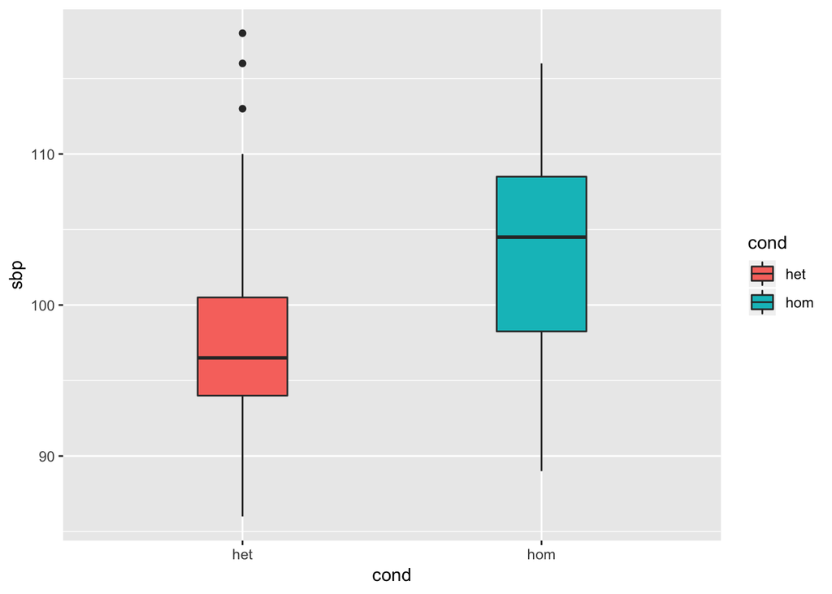

```r
het = c(86, 88, 89, 89, 92, 93, 94, 94, 94,
      95, 95, 96, 96, 97, 97, 98, 98, 99,
      99, 101, 106, 107, 110, 113, 116, 118)
hom = c(89, 90, 92, 93, 93, 96, 99, 99, 99, 102,
  103, 104, 105, 106, 106, 107, 108, 108, 110, 110,
  112, 114, 116, 116)
cond = c(rep("het", length(het)), rep("hom", length(hom)))
dat <- data.frame( cond, sbp=c(het, hom) )
ggplot(dat, aes(x=cond, y=sbp, fill=cond)) +
  geom_boxplot(width=0.3)
```

## Permutation p-value

- QUESTION: What p-value do you get if you change the permutation number to 10,000?

```r
set.seed(2018)
diff.obs = mean(hom) - mean(het)
n.perm=5000
diff.perm=rep(NA, n.perm)
len.het=length(het)
len.hom=length(hom)
hethom = c(het, hom)
for (i in 1 : n.perm) {
    het.perm = sample(hethom, len.het, replace=TRUE)
    hom.perm = sample(hethom, len.hom, replace=TRUE)
    diff.perm[i] = mean(hom.perm) - mean(het.perm)
 }
p.perm = sum( abs(diff.perm) >= abs(diff.obs) ) / n.perm
print(p.perm)
```

```
## [1] 0.0412
```

## Parametric test

- QUESTION: How different were the p-values from the permutation and patermetric tests?

```r
print(p.perm)
```

```
## [1] 0.0412
```

```r
t.test(het, hom)$p.value
```

```
## [1] 0.04824252
```

```r
wilcox.test(het, hom, exact=FALSE)$p.value
```

```
## [1] 0.04417628
```

## Binomial distribution

- QUESTION: Suppose the probability of developing chronic bronchitis disease in any one household (where both parents are chronic bronchitics) is 0.05. How likely are infants in at least 3 out 20 households (where both parents are chronic bronchitics) to develop chronic bronchitis ?

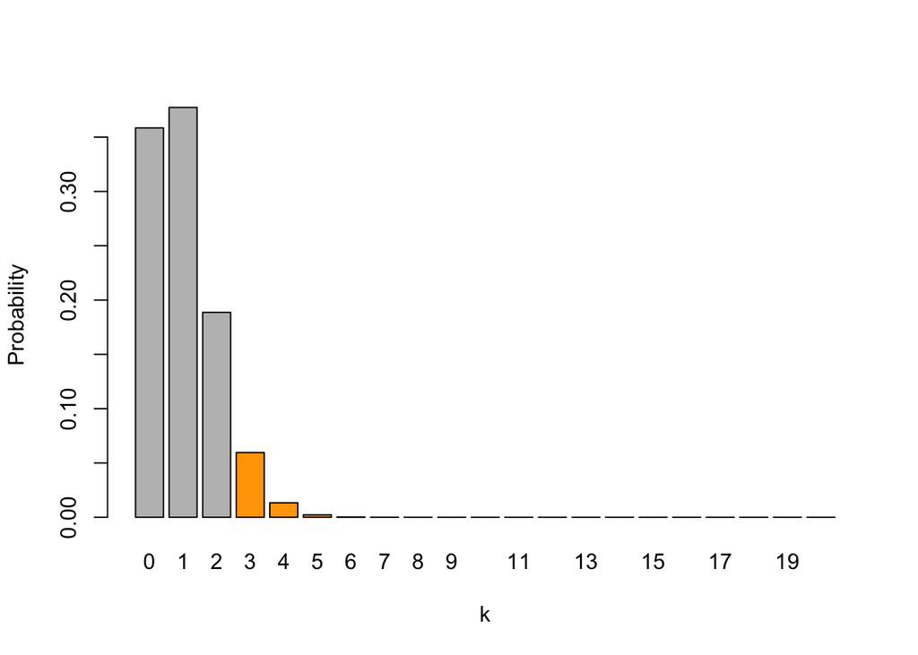

```r
numhouse = 0:20
cbProb <- dbinom(numhouse,  20, 0.05)
names(cbProb) = c(numhouse)
barplot(cbProb, ylab="Probability", xlab="k", col=ifelse(numhouse >= 3, "orange", "grey") )
```

## Poisson distribution

- QUESTION: Birth in a hospital occur randomly at an average rate of 1.8 births per hours. what is the probability of observing exactly 4 births in a given hour at the hospital? What about the probability of obeserving more than or equal to 2 births in a given hospital?

```r
dpois(4, lambda = 1.8)
```

```
## [1] 0.07230173
```

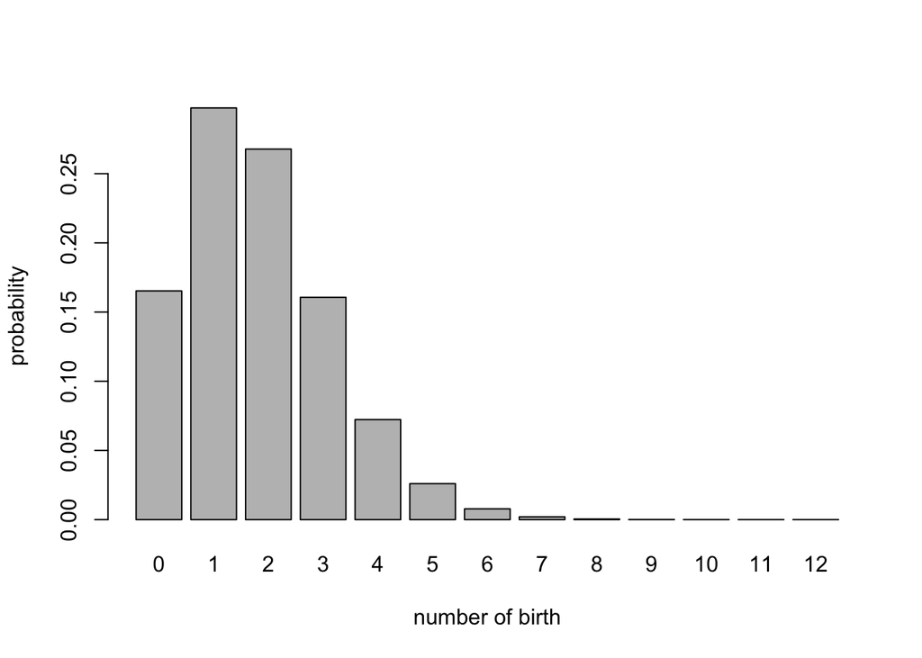

```r
countbirth = c(0:12)
probbirth = dpois(countbirth, lambda = 1.8)
names(probbirth) = countbirth
barplot(probbirth, ylab = "probability", xlab = "number of birth")
```

## Normal distribution

- QUESTION: Can you repeat the code below by generating numbers from the Chi-square distribution with degree of freedom 2 instead of Normal distribution?

```r
myRandomNumbers = rnorm(2000, 0, 1)
shapiro.test(myRandomNumbers)
```

```
##
##  Shapiro-Wilk normality test
##
## data:  myRandomNumbers
## W = 0.9993, p-value = 0.6775
```

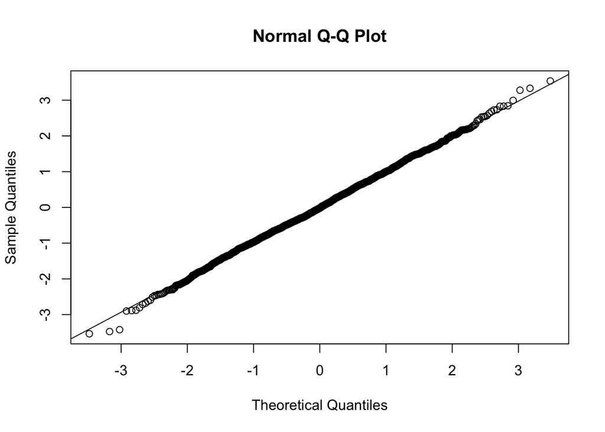

```r
qqnorm(myRandomNumbers)
qqline(myRandomNumbers)
```

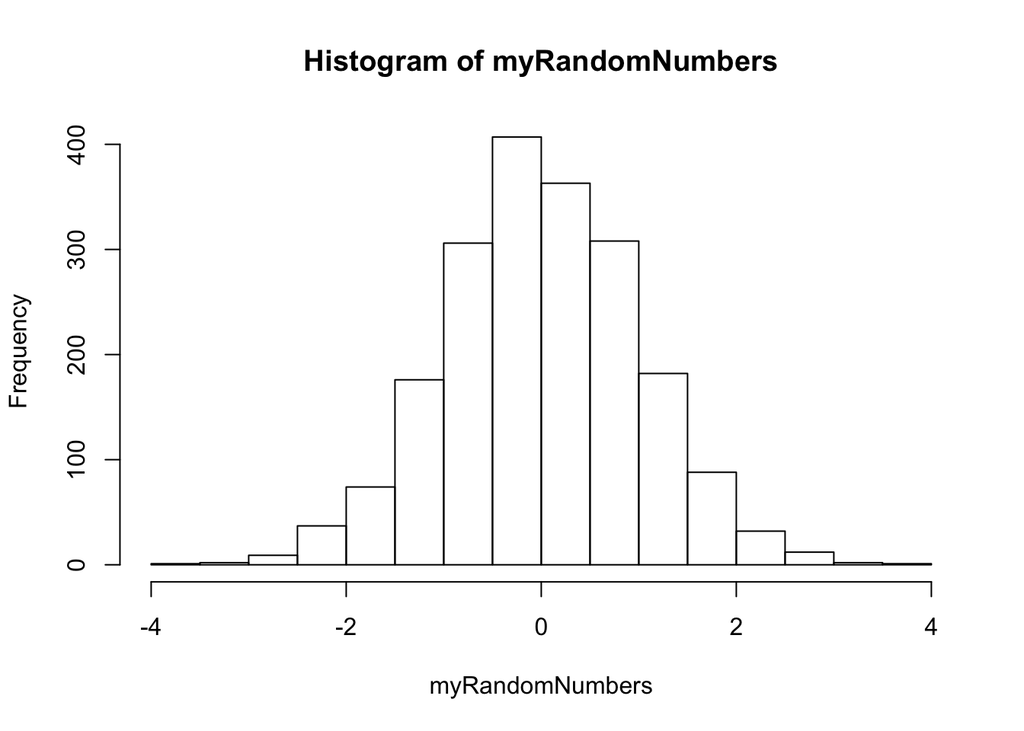

```r
hist(myRandomNumbers)
```

## Two-sample t-test

- QUESTION: Is there a significant difference in birth weight between smoker and non-smokers during pregnancy?

```r
data(birthwt)
head(birthwt)
```

```
##    low age lwt race smoke ptl ht ui ftv  bwt
## 85   0  19 182    2     0   0  0  1   0 2523
## 86   0  33 155    3     0   0  0  0   3 2551
## 87   0  20 105    1     1   0  0  0   1 2557
## 88   0  21 108    1     1   0  0  1   2 2594
## 89   0  18 107    1     1   0  0  1   0 2600
## 91   0  21 124    3     0   0  0  0   0 2622
```

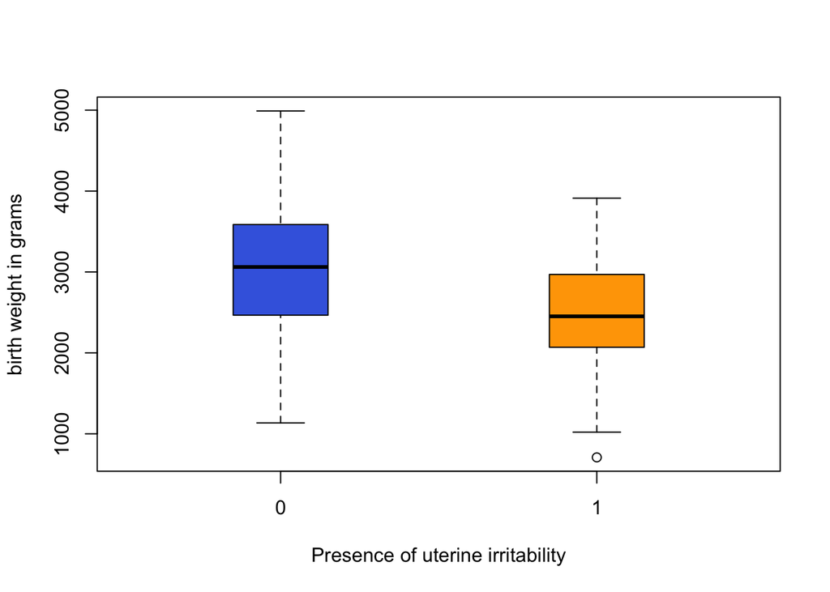

```r
boxplot( bwt ~ factor(ui), data = birthwt, boxwex=0.3,  col = c("royalblue", "orange"),
         ylab = "birth weight in grams", xlab = "Presence of uterine irritability")
```

```r
t.test( birthwt$bwt[birthwt$ui==1], birthwt$bwt[birthwt$ui==0], paired = FALSE)
```

```
##
##  Welch Two Sample t-test
##
## data:  birthwt$bwt[birthwt$ui == 1] and birthwt$bwt[birthwt$ui == 0]
## t = -3.8615, df = 35.696, p-value = 0.000455
## alternative hypothesis: true difference in means is not equal to 0
## 95 percent confidence interval:
##  -886.6553 -275.8913
## sample estimates:
## mean of x mean of y
##  2449.429  3030.702
```

## Wilcoxon rank-sum test, a non-parametric test for two independent samples

- QUESTION: Why might a t-test not be useful to ccompare the hospital Length Of Stay (LOS) between two hospitals A and B?

```r
LOS.hospitalA = c(21, 10, 32, 60, 8, 44, 29, 5, 13, 26, 33)
LOS.hospitalB = c(86, 27, 10, 68, 87, 76, 125, 60, 35, 73, 96, 44, 238)
wilcox.test(LOS.hospitalA , LOS.hospitalB)
```

```
##
##  Wilcoxon rank sum test with continuity correction
##
## data:  LOS.hospitalA and LOS.hospitalB
## W = 17.5, p-value = 0.001925
## alternative hypothesis: true location shift is not equal to 0
```

## Statistical power and sample size estimation

The power of a statistical test is the probability of correctly rejecting the null hypothesis when it is false and defined as 1 - beta = Pr(reject null hupothesis when it is false)

## Example: Coronary heart disease

- Consider a clinical trial for evaluation of the effect of a test drug on cholesterol in patients with coronary heart disease (CHD).
- Cholesterol is the main lipid associated with atherosclerotic vascular disease (ASVD). The purpose of cholesterol testing is to identify patients at risk for atherosclerosis.
- About 75% of the cholesterol is bound to low density lipoproteins (LDLs) and 25% to high density lipoproteins (HDLs). Of these, LDL is the most directly associate with increased risk of CHD.
- A pharmaceutical company is interested in conducting a clinical trial to compare two cholesterol lowering agents for treatment of patients with CHD through a parallel design. The primary efficacy parameter is the LDL.
- Suppose a difference of 5% in percent change of LDL is considered of clinically meaningful difference.
- Assume that the standard deviation is 10%.
- Reference: Chow,S et al. (2008) Sample size calculations in clinical research. Boca Raton,FL. Chapman and Hall/CRC.

QUESTION: What is the required sample size per group to achieve an 80% power at the 5% significance level?

```r
# DEFINE A FUNCTION
ss.two_sample_mean = function(sigma, epsilon, alpha, beta) {
    term.top =  (qnorm(1-alpha/2) + qnorm(beta) )^2 * sigma^2 * 2
    term.bottom <-  abs(epsilon)^2
    return(  ceiling( term.top / term.bottom ) )
}

# RUN A FUNCTION FOR A CORONARY HEART DISEASE EXAMPLE
ss.two_sample_mean(0.1, 0.05, 0.05, 0.8)
```

```
## [1] 63
```

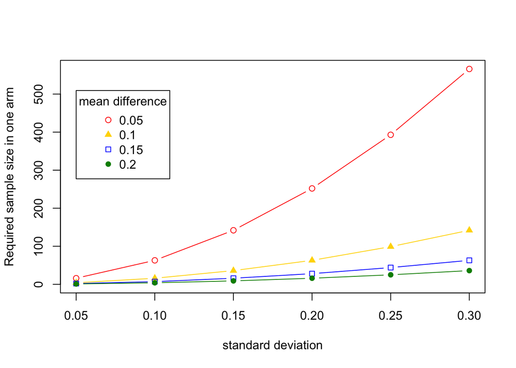

```r
# [1] 63

# VARY PARAMETERS
my.sigma = seq(0.05, 0.3, 0.05); my.epsilon = seq(0.05, 0.2, 0.05)
len.sigma = length(my.sigma); len.epsilon = length(my.epsilon);
my.ssize = matrix(1, nrow=len.sigma, ncol=len.epsilon, byrow=TRUE)
for(i in 1:len.sigma) {
   for(j in 1:len.epsilon) {
      my.ssize[i,j] = ss.two_sample_mean(my.sigma[i], my.epsilon[j], 0.05, 0.8)
    }
}

# DRAW A PLOT
my.color = c("red", "gold", "blue", "green4")
plot(my.sigma, my.ssize[,1], type="b", ylim=c(0, max(my.ssize)), col = my.color[1],
      xlab="standard deviation", ylab="Required sample size in one arm" )
points(my.sigma, my.ssize[,2], type="b", pch=17, col=my.color[2] )
points(my.sigma, my.ssize[,3], type="b", pch=22, col=my.color[3] )
points(my.sigma, my.ssize[,4], type="b", pch=16, col=my.color[4] )
legend(my.sigma[1], max(my.ssize)*0.9,  legend=my.epsilon, pch=c(1, 17, 22, 16),
    col = my.color, title="mean difference"  )
```

## Logistic Regression with birth weight data

- low: indicator of birth weight less than 2.5 kg.
- age: mother’s age in years.
- lwt: mother’s weight in pounds at last menstrual period.
- race: mother’s race (1 = white, 2 = black, 3 = other).
- smoke: smoking status during pregnancy.
- ptl: number of previous premature labours.
- ht: history of hypertension.
- ui: presence of uterine irritability.
- ftv: number of physician visits during the first trimester.
- bwt: birth weight in grams.

```r
data(birthwt)
bwt.df <- with(birthwt, {
  race <- factor(race, labels = c("white", "black", "other"))
  ptd <- factor(ptl > 0)
  ftv <- factor(ftv)
  levels(ftv)[-(1:2)] <- "2+"
  data.frame(low = factor(low), bwt, age, lwt, race, smoke = (smoke > 0),
             ptd, ht = (ht > 0), ui = (ui > 0), ftv)
})
head(bwt.df)
```

```
##   low  bwt age lwt  race smoke   ptd    ht    ui ftv
## 1   0 2523  19 182 black FALSE FALSE FALSE  TRUE   0
## 2   0 2551  33 155 other FALSE FALSE FALSE FALSE  2+
## 3   0 2557  20 105 white  TRUE FALSE FALSE FALSE   1
## 4   0 2594  21 108 white  TRUE FALSE FALSE  TRUE  2+
## 5   0 2600  18 107 white  TRUE FALSE FALSE  TRUE   0
## 6   0 2622  21 124 other FALSE FALSE FALSE FALSE   0
```

## Exploratory Data Analysis

- QUESTION: Can you create a similar boxplot of bwt along smoking status?

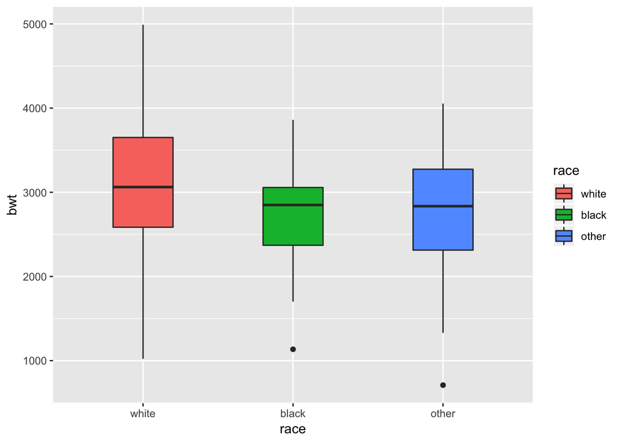

```r
### Exploratory data analysis
ggplot(bwt.df, aes(x=race, y=bwt, fill=race)) + geom_boxplot(width=0.4)
```

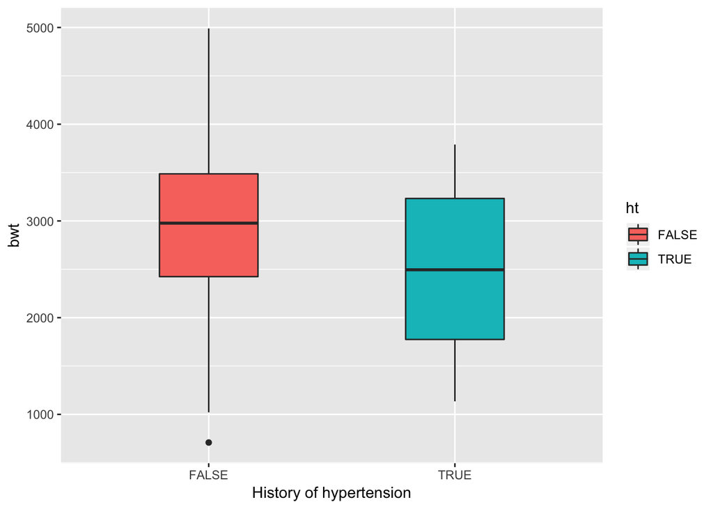

```r
ggplot(bwt.df, aes(x=ht, y=bwt, fill=ht)) +
  geom_boxplot(width=0.4) + xlab("History of hypertension")
```

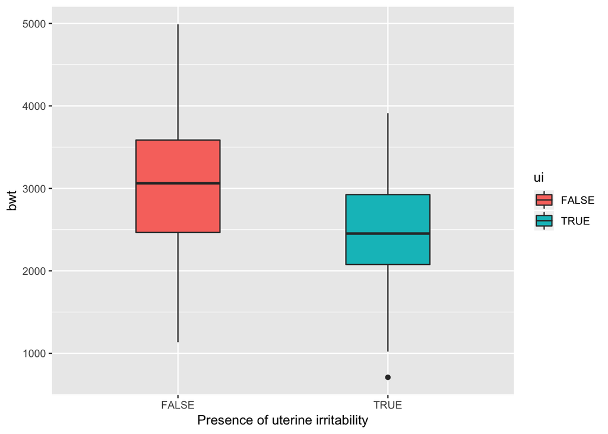

```r
ggplot(bwt.df, aes(x=ui, y=bwt, fill=ui) ) +
  geom_boxplot(width=0.4) + xlab("Presence of uterine irritability")
```

## Fit a logistic regression model

- QUESTION: Which variable is the most significant and what is the odds ratio?

```r
bwt <- with(birthwt, {
  race <- factor(race, labels = c("white", "black", "other"))
  ptd <- factor(ptl > 0)
  ftv <- factor(ftv)
  levels(ftv)[-(1:2)] <- "2+"
  data.frame(low = factor(low), age, lwt, race, smoke = (smoke > 0),
             ptd, ht = (ht > 0), ui = (ui > 0), ftv)
})
options(contrasts = c("contr.treatment", "contr.poly"))
m1 = glm(low ~ ., data = bwt, family = "binomial")
summary(m1)$coef
```

```
##                Estimate Std. Error    z value    Pr(>|z|)
## (Intercept)  0.82301896 1.24471433  0.6612111 0.508476929
## age         -0.03723429 0.03870238 -0.9620671 0.336015876
## lwt         -0.01565301 0.00708041 -2.2107487 0.027053243
## raceblack    1.19241321 0.53596458  2.2247986 0.026094765
## raceother    0.74068488 0.46174434  1.6041017 0.108691633
## smokeTRUE    0.75552837 0.42501665  1.7776442 0.075462312
## ptdTRUE      1.34376338 0.48062070  2.7958916 0.005175676
## htTRUE       1.91316586 0.72073686  2.6544582 0.007943589
## uiTRUE       0.68019548 0.46434032  1.4648641 0.142957993
## ftv1        -0.43637967 0.47939359 -0.9102743 0.362677854
## ftv2+        0.17900852 0.45637777  0.3922376 0.694882668
```

## Model discrimination with Area Under the ROC Curve (AUC)

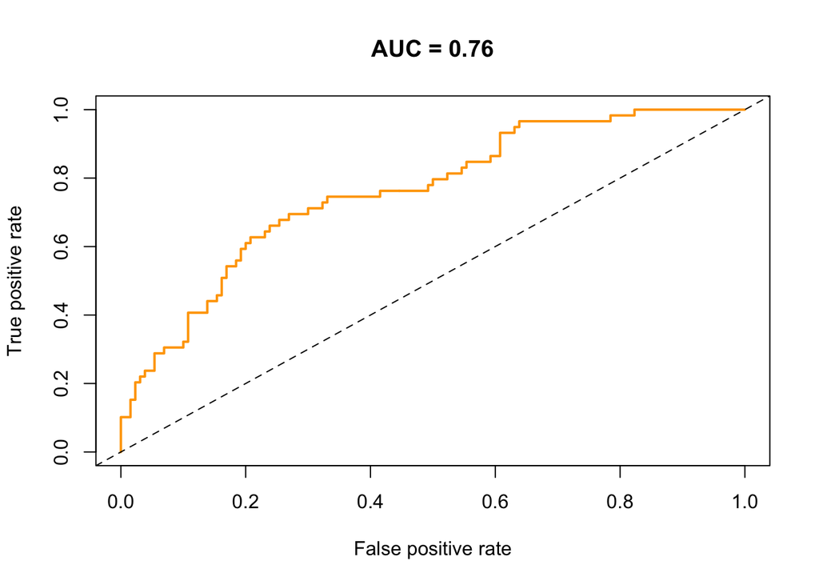

```r
mypred = prediction(m1$fitted.values, m1$y)
roc.perf = performance(mypred, measure = "tpr", x.measure = "fpr")
auc.perf = performance(mypred, measure = "auc")
plot(roc.perf, col = "orange", lwd = 2,
     main = paste ( "AUC = ", round(auc.perf@y.values[[1]], 2), sep="" )  )
abline(a = 0, b = 1, lty = 2)
```

## Model calibration with Hosmer-Lemeshow test

QUESTION: Which probability bin has the most ambiguous mix of two lables (low vs. normal)?

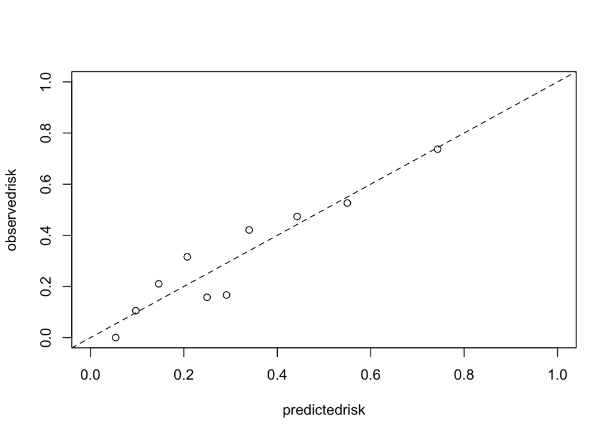

```r
myhl = hoslem.test(m1$y, m1$fitted.values, g=10)
calibplot = data.frame( observedrisk = myhl$observed[,2] / apply(myhl$observed, 1, sum),
                        predictedrisk = myhl$expected[,2] / apply(myhl$expected, 1, sum))
plot(   observedrisk ~ predictedrisk, data = calibplot,
       ylim = c(0, 1), xlim = c(0, 1))
abline(a = 0 , b = 1, lty = 2)
```

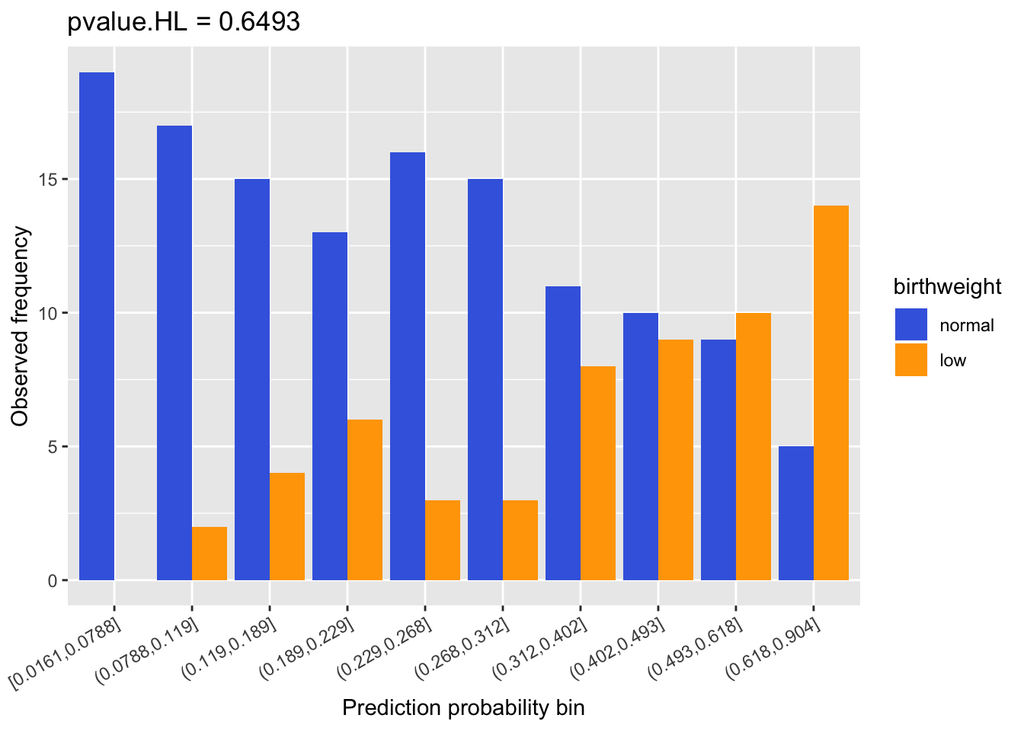

```r
mycalib = data.frame(
            predictionbin = factor(  c( rownames(myhl$observed),
                                        rownames(myhl$observed)),
                                    levels = rownames(myhl$observed)),
            observedfreq = c(myhl$observed[,1], myhl$observed[,2]),
            birthweight = factor( c( rep("normal", 10), rep("low", 10) ),
                                  levels = c("normal", "low")) )
ggplot(data=mycalib,
         aes(x=predictionbin, y=observedfreq, fill = birthweight)) +
      geom_bar(stat="identity", position=position_dodge()) +
      theme(axis.text.x=element_text(angle=30, hjust=1) ) +
     scale_fill_manual(values = c("royalblue", "orange")) +
     ylab("Observed frequency") +
     xlab("Prediction probability bin") +
     ggtitle( paste("pvalue.HL = ", round(myhl$p.value, 4), sep=""))
```

## Changes to the calibration

- QUESTION: Dividing prediction probabilities by 10 disrupts the model calibration. How much does the AUC value change?

```r
hoslem.test(m1$y, m1$fitted.values / 10, g=10)
```

```
##
##  Hosmer and Lemeshow goodness of fit (GOF) test
##
## data:  m1$y, m1$fitted.values/10
## X-squared = 548.19, df = 8, p-value < 2.2e-16
```

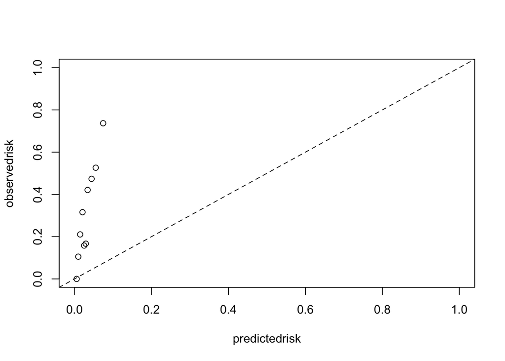

```r
myhl = hoslem.test(m1$y, m1$fitted.values/10, g=10)
calibplot = data.frame( observedrisk = myhl$observed[,2] / apply(myhl$observed, 1, sum),
                        predictedrisk = myhl$expected[,2] / apply(myhl$expected, 1, sum))
plot(   observedrisk ~ predictedrisk, data = calibplot,
       ylim = c(0, 1), xlim = c(0, 1))
abline(a = 0 , b = 1, lty = 2)
```

## Survival Anslysis

- The most important difference between the outcome variables modeled via linear/logistic regression and survival analysis is the fact that we may observe the survival time partially
- For those subjects who died, it is the outcome variable of interest, the actual survival time.
- However, for subjects who were alive at the end of the study, or for subjects who were lost, the time variable indicates the length of follow-up, which is a partial or incomplete observation of survival time
- These incomplete observations are referred to as being censored
- If we ignore the consoling and treat the censored observations as if they were measurements of survival time, then the resulting sample statistics are NOT estimators of the respective parameters of the survival time distribution.

## Survival analysis with lung cancer

Loprinzi et al. Journal of Clinical Oncology. 12(3):601-7, 1994.

- inst: Institution code
- time: Survival time in days
- status: censoring status 1=censored, 2=dead
- age: Age in years
- sex: Male=1 Female=2
- ph.ecog: ECOG performance score (0=good 5=dead)
- ph.karno: Karnofsky performance score (bad=0-good=100) rated by physician
- pat.karno: Karnofsky performance score as rated by patient
- meal.cal: Calories consumed at meals
- wt.loss: Weight loss in last six months

```r
data(lung)
head(lung)
```

```
##   inst time status age sex ph.ecog ph.karno pat.karno meal.cal wt.loss
## 1    3  306      2  74   1       1       90       100     1175      NA
## 2    3  455      2  68   1       0       90        90     1225      15
## 3    3 1010      1  56   1       0       90        90       NA      15
## 4    5  210      2  57   1       1       90        60     1150      11
## 5    1  883      2  60   1       0      100        90       NA       0
## 6   12 1022      1  74   1       1       50        80      513       0
```

```r
m1.surv = survfit( Surv(time,status) ~ sex, data = lung)
print(m1.surv)
```

```
## Call: survfit(formula = Surv(time, status) ~ sex, data = lung)
##
##         n events median 0.95LCL 0.95UCL
## sex=1 138    112    270     212     310
## sex=2  90     53    426     348     550
```

## Kaplan-Meier curve

- QUESTION: What is the median survival time for male?

```r
m1.diff = survdiff(Surv(time, status) ~ sex, data = lung)
m1.diff
```

```
## Call:
## survdiff(formula = Surv(time, status) ~ sex, data = lung)
##
##         N Observed Expected (O-E)^2/E (O-E)^2/V
## sex=1 138      112     91.6      4.55      10.3
## sex=2  90       53     73.4      5.68      10.3
##
##  Chisq= 10.3  on 1 degrees of freedom, p= 0.001
```

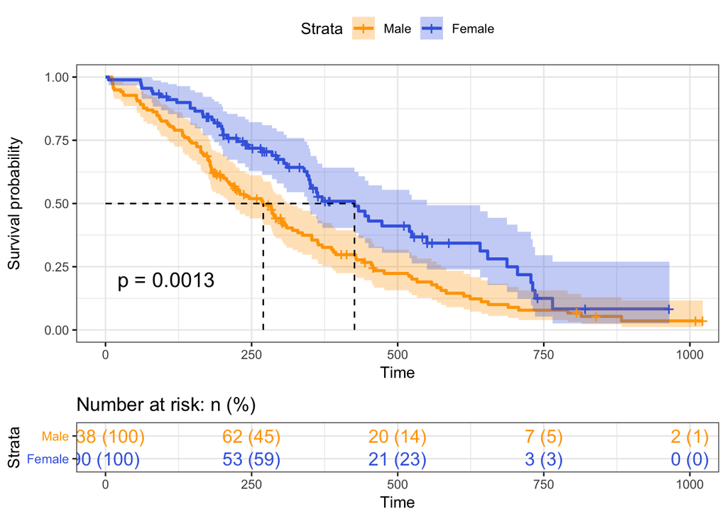

```r
ggsurvplot(m1.surv, data = lung, conf.int = TRUE, pval = TRUE,
           palette = c("orange", "royalblue"),
           legend.labs =  c("Male", "Female"), surv.median.line = "hv",
           risk.table = "abs_pct", risk.table.col = "strata", ggtheme = theme_bw() )
```

## Survival analysis: Cox Proportional Hazards (PH) model

```r
m.coxPH <- coxph(Surv(time, status) ~ age + sex + ph.ecog, data =  lung)
summary(m.coxPH)
```

```
## Call:
## coxph(formula = Surv(time, status) ~ age + sex + ph.ecog, data = lung)
##
##   n= 227, number of events= 164
##    (1 observation deleted due to missingness)
##
##              coef exp(coef)  se(coef)      z Pr(>|z|)
## age      0.011067  1.011128  0.009267  1.194 0.232416
## sex     -0.552612  0.575445  0.167739 -3.294 0.000986 ***
## ph.ecog  0.463728  1.589991  0.113577  4.083 4.45e-05 ***
## ---
## Signif. codes:  0 '***' 0.001 '**' 0.01 '*' 0.05 '.' 0.1 ' ' 1
##
##         exp(coef) exp(-coef) lower .95 upper .95
## age        1.0111     0.9890    0.9929    1.0297
## sex        0.5754     1.7378    0.4142    0.7994
## ph.ecog    1.5900     0.6289    1.2727    1.9864
##
## Concordance= 0.637  (se = 0.026 )
## Rsquare= 0.126   (max possible= 0.999 )
## Likelihood ratio test= 30.5  on 3 df,   p=1e-06
## Wald test            = 29.93  on 3 df,   p=1e-06
## Score (logrank) test = 30.5  on 3 df,   p=1e-06
```

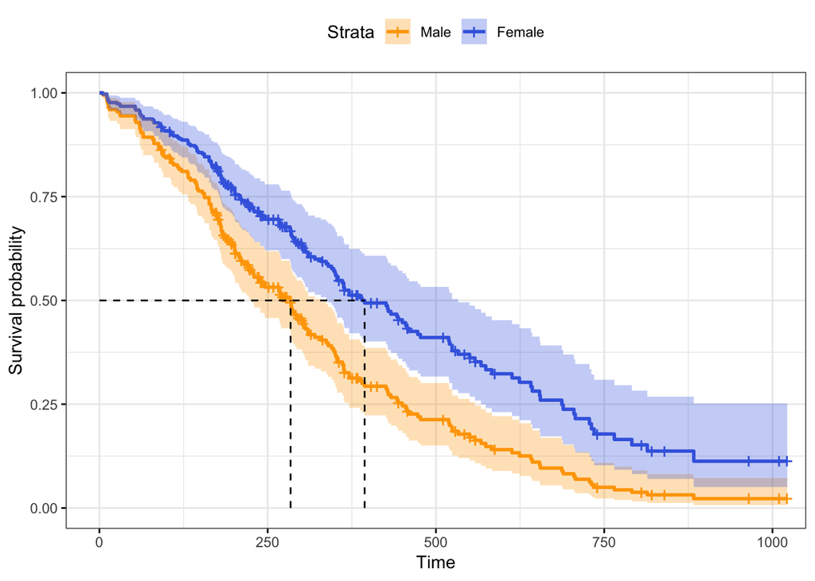

```r
sex_df <- with(lung,
               data.frame(sex = c(1, 2),
                          age = rep(mean(age, na.rm = TRUE), 2),
                          ph.ecog = c(1, 1)
               )
)
m2.surv <- survfit(m.coxPH, newdata = sex_df)
ggsurvplot(m2.surv, data = sex_df, conf.int = TRUE,
           palette = c("orange", "royalblue"),
           legend.labs= c("Male", "Female"),  surv.median.line = "hv",
           ggtheme = theme_bw() )
```

## Test proportional hazards (PH) assumption

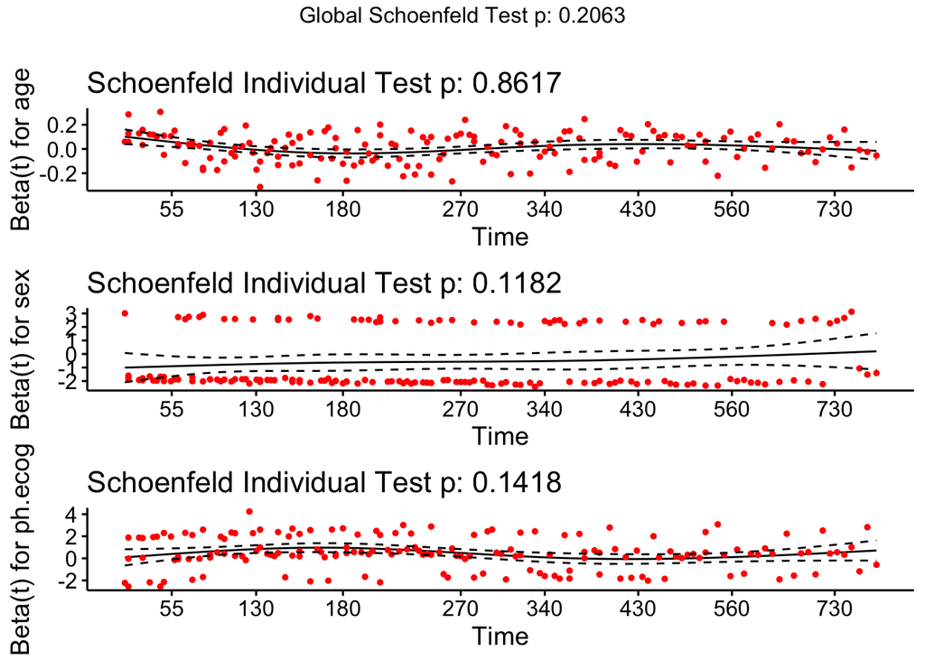

```r
m.zph = cox.zph(m.coxPH)
ggcoxzph(m.zph)
```

## Meta-analysis odds ratio

A randomised trial of corticosteroid therapy in premature labor and its effect on neonatal death.

```r
data( cochrane )
head( cochrane )
```

```
##           name ev.trt n.trt ev.ctrl n.ctrl
## 1     Auckland     36   532      60    538
## 2        Block      1    69       5     61
## 3        Doran      4    81      11     63
## 4        Gamsu     14   131      20    137
## 5     Morrison      3    67       7     59
## 6 Papageorgiou      1    71       7     75
```

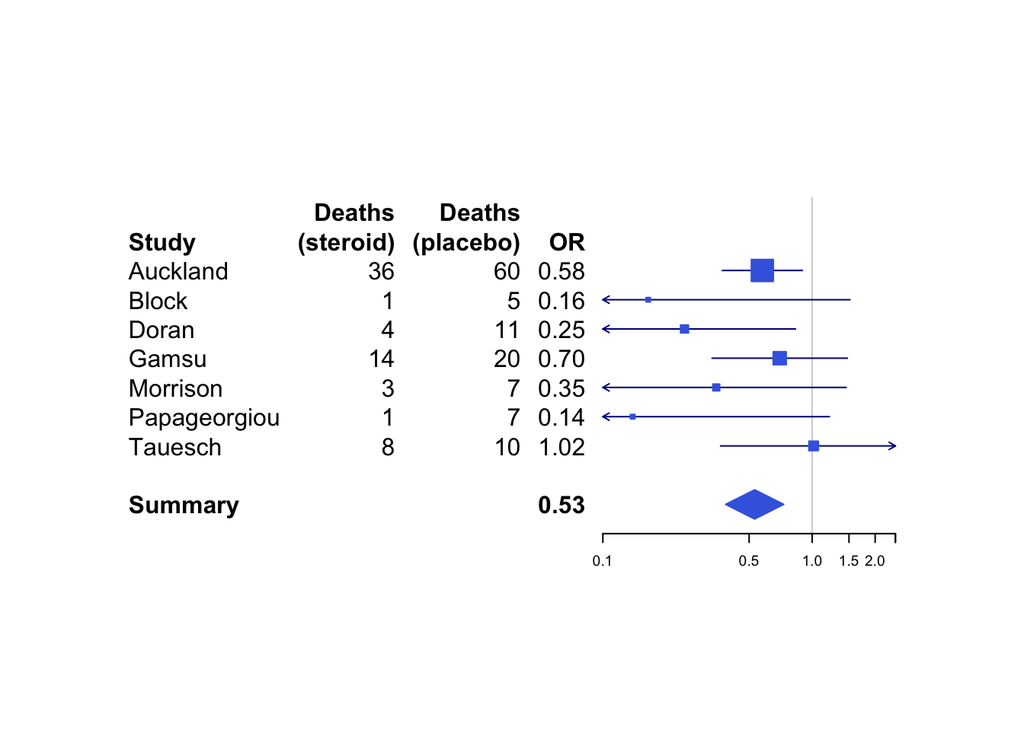

```r
steroid <- meta.MH(n.trt, n.ctrl,
                   ev.trt, ev.ctrl,
                   names=name, data=cochrane)
tabletext <- cbind(
  c("","Study",steroid$names,NA,"Summary"),
  c("Deaths","(steroid)",cochrane$ev.trt,NA,NA),
  c("Deaths","(placebo)", cochrane$ev.ctrl, NA,NA),
  c("","OR",format(exp(steroid$logOR),digits=2),NA,format(exp(steroid$logMH),digits=2))
)
m.ci <-     c(NA, NA, steroid$logOR,   NA, steroid$logMH)
l.ci <- m.ci - c(NA, NA, steroid$selogOR, NA, steroid$selogMH)*2
u.ci <- m.ci + c(NA, NA, steroid$selogOR, NA, steroid$selogMH)*2

forestplot(tabletext, m.ci, l.ci, u.ci, zero=0,
           is.summary=c(TRUE,TRUE,rep(FALSE,8),TRUE),
           clip=c(log(0.1),log(2.5)),
           xlog=TRUE,
           col=meta.colors(box="royalblue",
                           line="darkblue",
                           summary="royalblue"))
```